# Math 189: Logistic Regression I

# Classification on Synthetic Data

- We are interested in predicting whether an individual will default on his/her credit card payment, on the basis of annual income and monthly credit card balance.
- We study the “Default” data set from the package *ISLR*. It contains 10,000 individuals with 4 variables: default (Yes or No), student (Yes or No), balance, and income.
- Visualization: a scatter plot of monthly credit card balance versus annual income, with red marking individuals who defaulted on their credit card payments, and green corresponding to those who did not default.

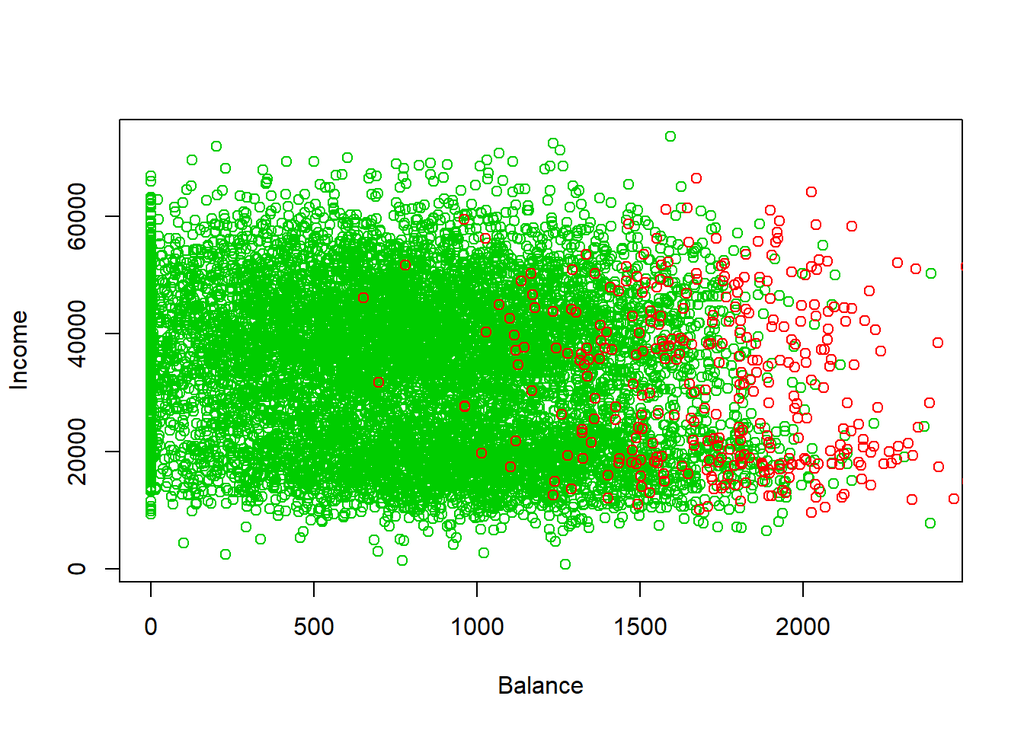

```r
library(ISLR)
data(Default)
Default_good <- Default[Default$default == "No",]
Default_bad <- Default[Default$default == "Yes",]
plot(x = Default_good$balance, y = Default_good$income,col=3,
     xlab = "Balance",ylab = "Income")
points(x = Default_bad$balance, y = Default_bad$income,col=2)
```

- Also some boxplots of balance and income as a function of default status.

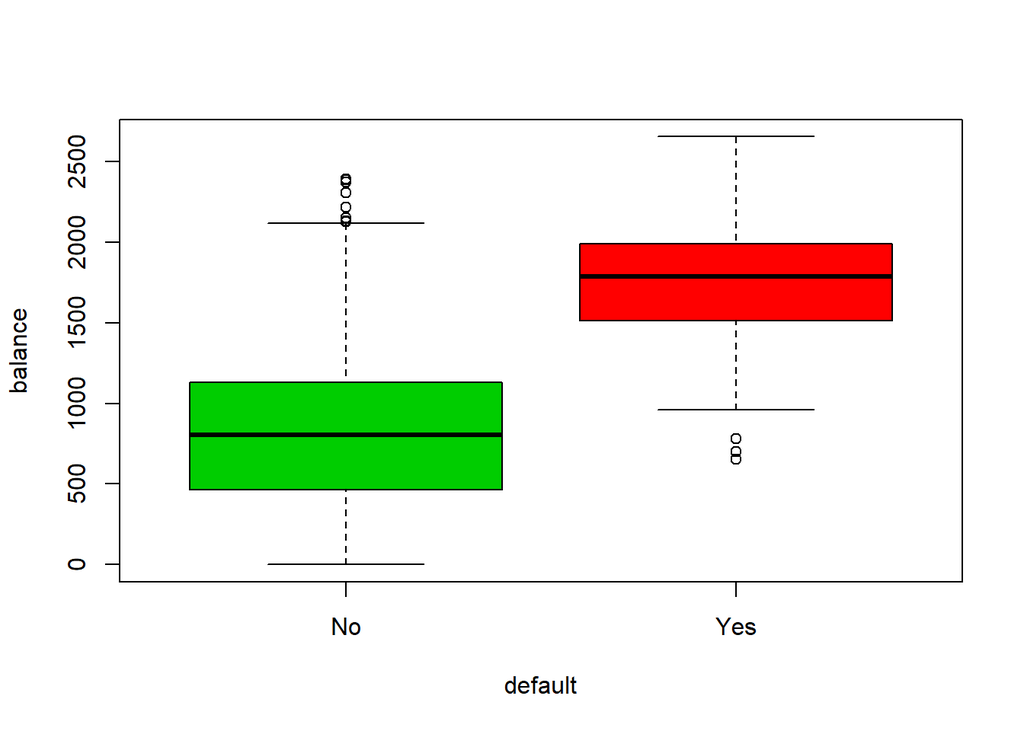

```r
boxplot(balance ~ default, data=Default, col=c(3,2))
```

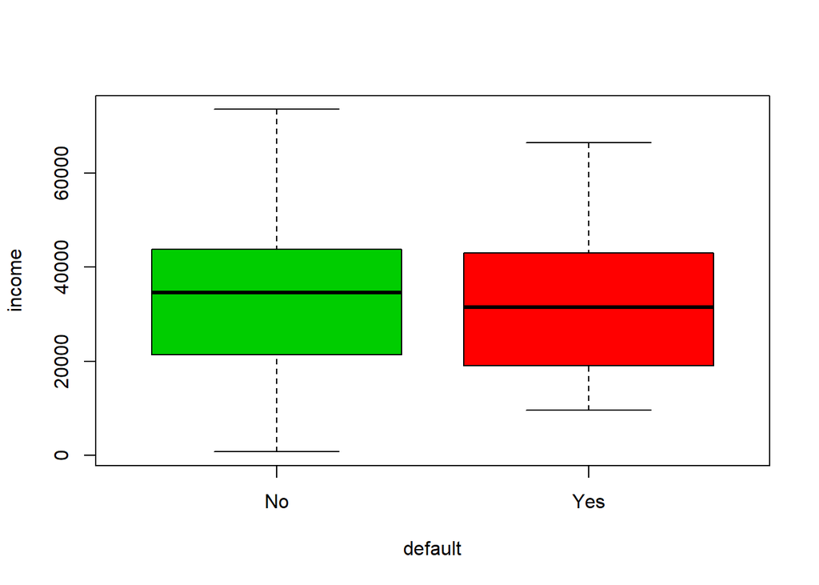

```r
boxplot(income ~ default, data=Default, col=c(3,2))
```

## Goal:

- We wish to build a model to predict “default” $Y$ for any given value of balance $X_1$ and income $X_2$.
- Logistic Regression: the response “default” falls into one of two categories, Yes or No.
- Logistic regression models the probability that $Y$ belongs to a particular category.
- Perhaps we want to know the probability of default given a balance value.
  $${\mathbb P} \left[ \mbox{default} = \mbox{Yes} \vert \mbox{balance} \right]$$
  Call this $p(\mbox{balance})$.
- Maybe a credit card company deems the risk of default to be high whenever $p(\mbox{balance}) > 1/2$. They could use a lower threshold if they want to control more risk.

## The Logistic Model

- Let Yes be $1$ and No be $0$.
- Consider the conditional probability
  $$p(x) = {\mathbb P} [ Y = 1 \vert X = x ]$$
- We want to model $p(x)$ using a function that gives outputs between $0$ and $1$ for all values of $x$. Many functions meet this criterion.
- In logistic regression, we use the *logistic function*.
  $$p(x) = \frac{ \exp \{ \beta_0 + \beta_1 x \} }{ 1 + \exp \{ \beta_0 + \beta_1 x \} }$$
- To fit this model, we use a method called *maximum likelihood estimation*.
- Note that
  $$\frac{p(x)}{1 - p(x)} = \exp \{ \beta_0 + \beta_1 x \}$$
  The left-hand side is called the *odds*.
- Values of the odds close to 0 indicate very low probabilities of default.
- Values of the odds close to $\infty$ indicate very high probabilities of default.

### Example

- On average, 1 in 5 people with an odds of $1/4$ will default, since $p(x) = 0.2$ implies an odds of 1/4.
- Likewise, on average 9 out of every 10 people with an odds of 9 will default. Because: odds of $9$ implies $p(x) = .9$.
- Odds are traditionally used instead of probabilities in horseracing, since they relate more naturally to the correct betting strategy.

## Estimating the Regression Coefficients

- Intuition: We seek estimates for $\beta_0$ and $\beta_1$ such that the predicted probability $\widehat{p}(x)$ of default for each individual corresponds as closely as possible to the individual’s observed default status.
- Suppose we have data ${( y_i, x_i)}_{i=1}^n$.
- Likelihood function: by model assumption, ${\mathbf P} [ y_i=1 \vert x_i] = p(x_i)$ and ${\mathbf P} [ y_i=0 \vert x_i] = 1-p(x_i)$. So the conditional “density function” of $y_i$ given $x_i$ can be written compactly as
  $${ p(x_i)}^{y_i} { ( 1 - p(x_i))}^{1 - y_i}$$
- The joint conditional density of $y_1, \ldots, y_n$ given $x_1, \ldots, x_n$ is
  $$L_n (\beta_0, \beta_1) = \prod_{i=1}^n { p(x_i)}^{y_i} { ( 1 - p(x_i))}^{1 - y_i}$$
- This is a function of $\beta_0$ and $\beta_1$, because our model assumption is that
  $$p(x_i) = \frac{ \exp \{ \beta_0 + \beta_1 x_i \} }{ 1 + \exp \{ \beta_0 + \beta_1 x_i \} }$$
- The estimates $\widehat{\beta}_0$ and $\widehat{\beta}_1$ are chosen to maximize this likelihood function.
- How to maximize? Calculus, or nonlinear optimization. Use the computer!
- The logistic regression model can be fitted using a statistical software package, such as *glm* in R.

### Results on Default Data

The following table shows the coefficient estimates and related information that result from fitting a logistic regression model on the Default data in order to predict the probability of default, using balance.

```r
y <- as.numeric(Default$default=="Yes")
## Use the credit card balance to predict default probability
balance.fit <- glm(y~balance, data=Default,family=binomial)
summary(balance.fit)
```

```
##
## Call:
## glm(formula = y ~ balance, family = binomial, data = Default)
##
## Deviance Residuals:
##     Min       1Q   Median       3Q      Max
## -2.2697  -0.1465  -0.0589  -0.0221   3.7589
##
## Coefficients:
##               Estimate Std. Error z value Pr(>|z|)
## (Intercept) -1.065e+01  3.612e-01  -29.49   <2e-16 ***
## balance      5.499e-03  2.204e-04   24.95   <2e-16 ***
## ---
## Signif. codes:  0 '***' 0.001 '**' 0.01 '*' 0.05 '.' 0.1 ' ' 1
##
## (Dispersion parameter for binomial family taken to be 1)
##
##     Null deviance: 2920.6  on 9999  degrees of freedom
## Residual deviance: 1596.5  on 9998  degrees of freedom
## AIC: 1600.5
##
## Number of Fisher Scoring iterations: 8
```

- The glm() function fits generalized linear models, a class of models that includes logistic regression. When we use it in this way, we must pass in the argument *family=binomial* in order to tell R to run a logistic regression rather than some other type of generalized linear model.
- The $Z$-statistic here plays the same role as the $t$-statistic. For example, the $Z$-statistic associated with $\beta_1$ is $\widehat{\beta}_1/\mbox{se}(\widehat{\beta}_1)$. Large (absolute) values of the $Z$-statistic indicate evidence against the null hypothesis $H_0: \beta_1 = 0$.
- The null hypothesis $H_0: \beta_1 = 0$ implies that
  $$p(X) = {\mathbf P} [ Y = 1 \vert X = x] =
  \frac{ \exp \{ \beta_0 \} }{ 1 + \exp \{ \beta_0 \} }$$
  In other words, the probability of default does not depend on balance under the null hypothesis. Since the p-value associated with balance is tiny, we can reject $H_0$. We conclude that there is indeed an association between balance and the probability of default.

# Making Predictions

- Once the coefficients have been estimated, it is a simple matter to compute the probability of default for any given credit card balance.

```r
pred_balance <- function(obs_balance){
  x <- c(1,obs_balance)
  pred <- as.numeric(as.numeric(x %*% balance.fit$coefficients))
  pred <- 1/(1+exp(-pred))
  return(pred)
}
```

- Using the coefficient estimates, we predict that the default probability for an individual with a balance of 1000 dollars is
  $$\widehat{p} (1000) = \frac{ \exp \{ \widehat{\beta}_0 + \widehat{\beta}_1 (1000) \} }{ 1 + \exp \{ \widehat{\beta}_0 + \widehat{\beta}_1 (1000) \} },$$
  which is 0.0057521.
- The predicted probability of default for an individual with a balance of 2000 dollars is much higher: 0.5857694.
- Alternatively, one may predict the probability of default from student status. To see this, create a dummy variable that takes on a value of 1 for students and 0 for non-students.

```r
stu <- as.numeric(Default$student=="Yes")
student.fit <- glm(y~stu,data=Default,family=binomial)
summary(student.fit)
```

```
##
## Call:
## glm(formula = y ~ stu, family = binomial, data = Default)
##
## Deviance Residuals:
##     Min       1Q   Median       3Q      Max
## -0.2970  -0.2970  -0.2434  -0.2434   2.6585
##
## Coefficients:
##             Estimate Std. Error z value Pr(>|z|)
## (Intercept) -3.50413    0.07071  -49.55  < 2e-16 ***
## stu          0.40489    0.11502    3.52 0.000431 ***
## ---
## Signif. codes:  0 '***' 0.001 '**' 0.01 '*' 0.05 '.' 0.1 ' ' 1
##
## (Dispersion parameter for binomial family taken to be 1)
##
##     Null deviance: 2920.6  on 9999  degrees of freedom
## Residual deviance: 2908.7  on 9998  degrees of freedom
## AIC: 2912.7
##
## Number of Fisher Scoring iterations: 6
```

- The coefficient for the dummy variable is positive, and the associated $Z$-value is statistically significant. This indicates that students tend to have higher default probabilities than non-students.

```r
pred_student <- function(obs_student){
  x <- c(1,obs_student)
  pred <- as.numeric(as.numeric(x %*% student.fit$coefficients))
  pred <- 1/(1+exp(-pred))
  return(pred)
}
```

- Then we can predict the risk of default
  $$\begin{align*}
  & \widehat{\mathbb P} [ \mbox{default} = \mbox{Yes} \vert \mbox{Student} = \mbox{Yes} ]
  = \frac{ \exp \{ \widehat{\beta}_0 + \widehat{\beta}_1 (1) \} }{ 1 + \exp \{ \widehat{\beta}_0 + \widehat{\beta}_1 (1) \} }
  & \widehat{\mathbb P} [ \mbox{default} = \mbox{Yes} \vert \mbox{Student} = \mbox{No} ]
  = \frac{ \exp \{ \widehat{\beta}_0 + \widehat{\beta}_1 (0) \} }{ 1 + \exp \{ \widehat{\beta}_0 + \widehat{\beta}_1 (0) \} }
  \end{align*}$$
  for students 0.0431386 and non-students 0.029195.